# SARFRAZ_HW_6

Hussain Sarfraz

2/19/2022

# Question 1

## Part A

- I used the `load()` function to load in the `acs` dataset.
- I then divided the `median.income` variable by $1,000 so each number can be expressed in thousands of dollars. I did this so it could be easier to see the unit changes when I graph the `median.income` variable.

```r
load('C:/Users/hussainsarfraz/Desktop/DATA 310/Week 6/ACSCountyData (1).Rdata')
acs$median.income <- acs$median.income / 1000
```

## Part B

When I see the **Relationship between Median Income and Child Poverty** scatter plot I notice that the points take a downward slope shape as median income increases. The points do not decrease in a linear manner in the sense that they gradually decrease as the median income increases.

From looking at the scatter plot I can see that as the median income increases the percentage of child poverty decreases which means that when people earn higher income the percentage of children in poverty declines.

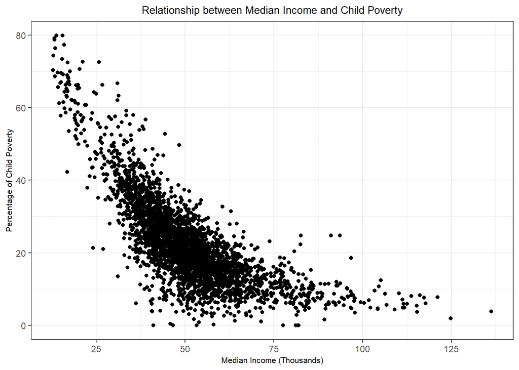

```r
ggplot(data=acs) +
  geom_point(aes(x = median.income, y = percent.child.poverty)) +
  xlab("Median Income (Thousands)") +
  ylab("Percentage of Child Poverty") +
  scale_x_continuous(breaks=c(0,25,50,75,100,125,150)) +
  ggtitle("Relationship between Median Income and Child Poverty") +
  theme_bw() +
  theme(plot.title = element_text(hjust = 0.5)) +
  theme(axis.title.x = element_text(size = 8),
        axis.title.y = element_text(size = 8),
        plot.title = element_text(size = 10))
```

## Part C

**NOTE**: I am using the symbols in the math equation $y=mx+b$ to represent the bi-variate linear regression

| Regression Values | What it Means |
| --- | --- |
| $b=53.584098$ | y-intercept |
| $m=-0.613294$ | slope |
| $x$ | input (independent variable) |
| $y$ | output (dependent variable) |

When I ran the bi-variate regression in R `summary(lm(percent.child.poverty~median.income, data=acs))` I got the above results. I have gave a detailed description below about what each number means:

- The **y-intercept** means when $x=0$ (meaning when no body is earning a income) then the child poverty rate would be at **53.584098**
- The **slope** means that for every unit increase in `median.income` the child poverty rate would decrease by **-0.613294** percent. This makes sense because as people earn more income there is a lower chance of children being in poverty because parents can provide for their kids education and well-being.

When looking at the scatter plot you can see that the numbers that the bi-variate regression function produced are correct since the y-intercept ($b$) appears to be close to **53.584098** and the slope ($m$) decreases the output of the regression line ($y$). That is why the regression line is decreasing.

```r
summary(lm(percent.child.poverty~median.income, data=acs))
```

```
##
## Call:
## lm(formula = percent.child.poverty ~ median.income, data = acs)
##
## Residuals:
##     Min      1Q  Median      3Q     Max
## -28.376  -4.879  -0.690   4.021  35.773
##
## Coefficients:
##                Estimate Std. Error t value Pr(>|t|)
## (Intercept)   53.584098   0.511495  104.76   <2e-16 ***
## median.income -0.613294   0.009686  -63.31   <2e-16 ***
## ---
## Signif. codes:  0 '***' 0.001 '**' 0.01 '*' 0.05 '.' 0.1 ' ' 1
##
## Residual standard error: 7.943 on 3216 degrees of freedom
##   (2 observations deleted due to missingness)
## Multiple R-squared:  0.5549, Adjusted R-squared:  0.5547
## F-statistic:  4009 on 1 and 3216 DF,  p-value: < 2.2e-16
```

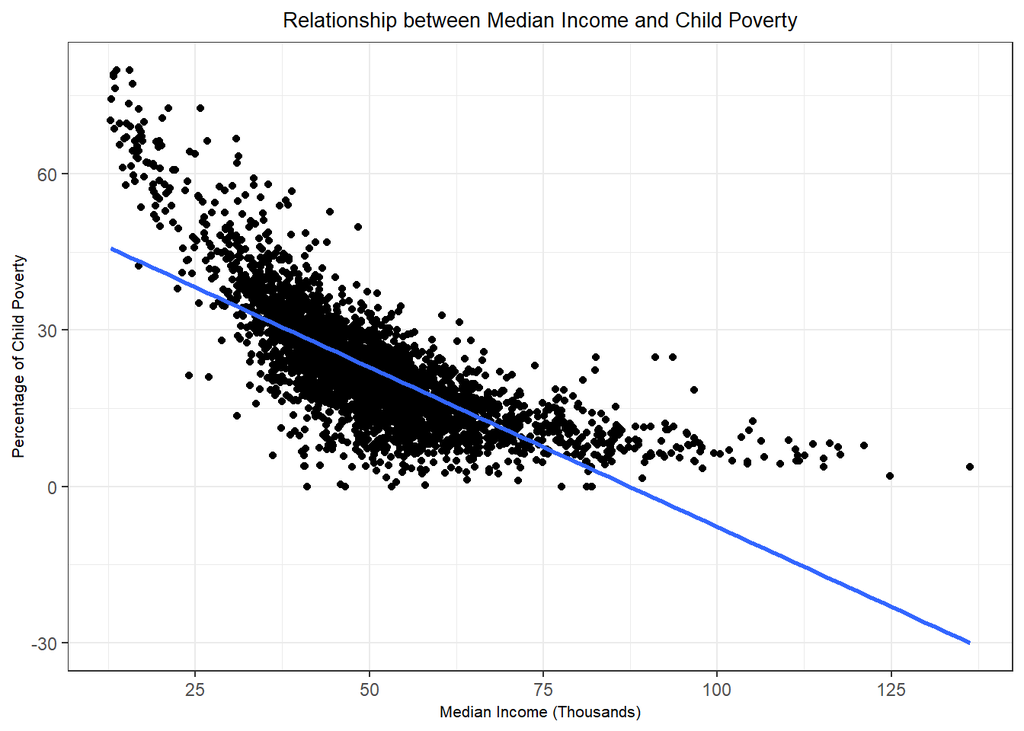

```r
ggplot(data=acs,aes(x = median.income, y = percent.child.poverty)) +
  geom_point() +
  geom_smooth(method=lm, formula = y ~ poly(x, 1), se = FALSE) +
  xlab("Median Income (Thousands)") +
  ylab("Percentage of Child Poverty") +
  scale_x_continuous(breaks=c(0,25,50,75,100,125,150)) +
  ggtitle("Relationship between Median Income and Child Poverty") +
  theme_bw() +
  theme(plot.title = element_text(hjust = 0.5)) +
  theme(axis.title.x = element_text(size = 8),
        axis.title.y = element_text(size = 8),
        plot.title = element_text(size = 10))
```

## Part D

When looking at the bi-variate linear regression graph in **part c** I realized that the regression does not satisfy **assumption 2** of the **Gauss-Markov Theory**.

Assumption 2 of the Gauss-Markov Theory states that the true model that generates our data is: $Y_{i} = \alpha + \beta_{1}*x_{i1} + \beta_{2}*x_{i2} + ... + \beta_{k}*x_{ik} + \epsilon_{i}$

When looking at the bi-variate regression line in **part c** you could see that at around a median income between **80-100 thousand dollars** the regression line goes off in a tangent and goes further away from the data points in the plot. According to the Gauss-Markov Theory this is inaccurate since the model (mentioned above) generates a true representation of the data.

To make my bi-variate regression line an accurate representation of the data I would need to add the square of `median.income` to the **linear** bi-variate regression line by changing the value of `poly(x,1)` to `poly(x,2)`. This would make the bi-variate regression into a curve and it would surround more data points as opposed to the **linear** bi-variate regression line.

The new **polynomial/curved** bi-variate regression line improves the model fit since the line now surrounds most of the data points. But when we use data to inform us about a lines function form we **increase** the risk of over-fitting our model fit. This is what has occurred with the **polynomial/curved** bi-variate regression line. Here are a few limitations of the **polynomial/curved** bi-variate regression line:

- The y-intercept is not accurately represented through the line.
- Around a median income of **100-150 thousand dollars** the slope of the bi-variate regression line increases which in not accurate since the increase in slope means that when people earn higher income the child poverty rate increase. This **conflicts** with what was shown at the beginning of the **polynomial/curved** bi-variate regression line where there was a **negative** slope.

There are also changes with $R^2$ in the **linear** bi-variate regression line and **polynomial/curved** bi-variate regression line models.

| $R^2$ Value | **linear** or **polynomial/curved** bi-variate regression line model |
| --- | --- |
| $R^2=0.5549$ | **linear** bi-variate regression line model |
| $R^2= 0.7039$ | **polynomial/curved** bi-variate regression line model |

```r
summary(lm(percent.child.poverty~poly(median.income,2,raw=T), data=acs))
```

```
##
## Call:
## lm(formula = percent.child.poverty ~ poly(median.income, 2, raw = T),
##     data = acs)
##
## Residuals:
##     Min      1Q  Median      3Q     Max
## -32.211  -3.739   0.092   3.901  27.695
##
## Coefficients:
##                                    Estimate Std. Error t value Pr(>|t|)
## (Intercept)                      87.6726812  0.9445253   92.82   <2e-16 ***
## poly(median.income, 2, raw = T)1 -1.8952449  0.0328318  -57.73   <2e-16 ***
## poly(median.income, 2, raw = T)2  0.0111246  0.0002765   40.23   <2e-16 ***
## ---
## Signif. codes:  0 '***' 0.001 '**' 0.01 '*' 0.05 '.' 0.1 ' ' 1
##
## Residual standard error: 6.479 on 3215 degrees of freedom
##   (2 observations deleted due to missingness)
## Multiple R-squared:  0.7039, Adjusted R-squared:  0.7037
## F-statistic:  3822 on 2 and 3215 DF,  p-value: < 2.2e-16
```

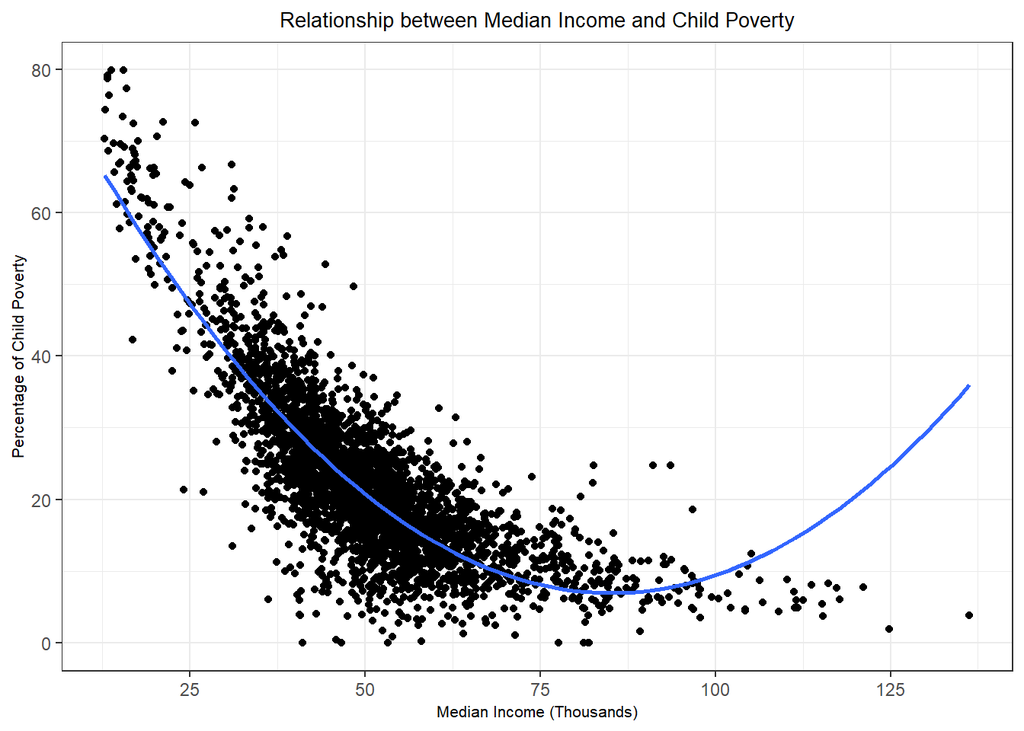

```r
ggplot(data=acs,aes(x = median.income, y = percent.child.poverty)) +
  geom_point() +
  geom_smooth(method=lm, formula = y ~ poly(x, 2), se = FALSE) +
  xlab("Median Income (Thousands)") +
  ylab("Percentage of Child Poverty") +
  scale_x_continuous(breaks=c(0,25,50,75,100,125,150)) +
  ggtitle("Relationship between Median Income and Child Poverty") +
  theme_bw() +
  theme(plot.title = element_text(hjust = 0.5)) +
  theme(axis.title.x = element_text(size = 8),
        axis.title.y = element_text(size = 8),
        plot.title = element_text(size = 10))
```

## Part E

At around $\$30k$ thousand dollars an effect of an additional $\$1000$ in median income would **decrease** the percentage of child poverty. This is because the slope of the polynomial/curved bi-variate regression line is **negative**.

At around $\$100k$ thousand dollars an effect of an additional $\$1000$ in median income would **increase** the percentage of child poverty. This is because the slope of the polynomial/curved bi-variate regression line is **positive**.

The difference in slope does make theoretical sense because as a I explained in **part D**:

- When we use data to inform us about a lines function form we **increase** the risk of over-fitting our model fit.

## Part F

| Correlation Value | Variable Names |
| --- | --- |
| $-0.4990148$ | median.income and unemployment.rate |
| $-0.7448909$ | median.income and percent.child.poverty |
| $0.6814938$ | unemployment.rate and percent.child.poverty |

The least correlated variables are **median.income and unemployment.rate** and the most correlated variables are **median.income and percent.child.poverty**.

**unemployment.rate and percent.child.poverty** do have a strong correlation since the correlation score is $68.15\%$.

Now **unemployment.rate** does have a strong correlation with the dependent variable **percent.child.poverty** but is does not have a strong correlation with the independent variable **median.income**. This means that because **unemployment.rate** does not have a strong correlation with another independent variable the y-intercept ($b$) would decrease and the coefficient/slope of `median.income` would decrease.

I wanted to see the conflicting correlations of the `median.income` and `unemployment.rate` variables so I compared the regression lines of both graphs side by side (the dependent variable for both graphs was `percent.child.poverty`). After seeing how the regression lines for both graphs were going in opposite directions I could understand why the y-intercept ($b$) and the coefficient/slope of `median.income` would decrease after adding `unemployment.rate` to the regression.

```r
#median.income - unemployment.rate
cor(acs$median.income, acs$unemployment.rate, use="pairwise.complete") #-0.4990148
```

```
## [1] -0.4990148
```

```r
#median.income - percent.child.poverty
cor(acs$median.income, acs$percent.child.poverty, use="pairwise.complete") #-0.7448909
```

```
## [1] -0.7448909
```

```r
#unemployment.rate - percent.child.poverty
cor(acs$unemployment.rate, acs$percent.child.poverty, use="pairwise.complete") #0.6814938
```

```
## [1] 0.6814938
```

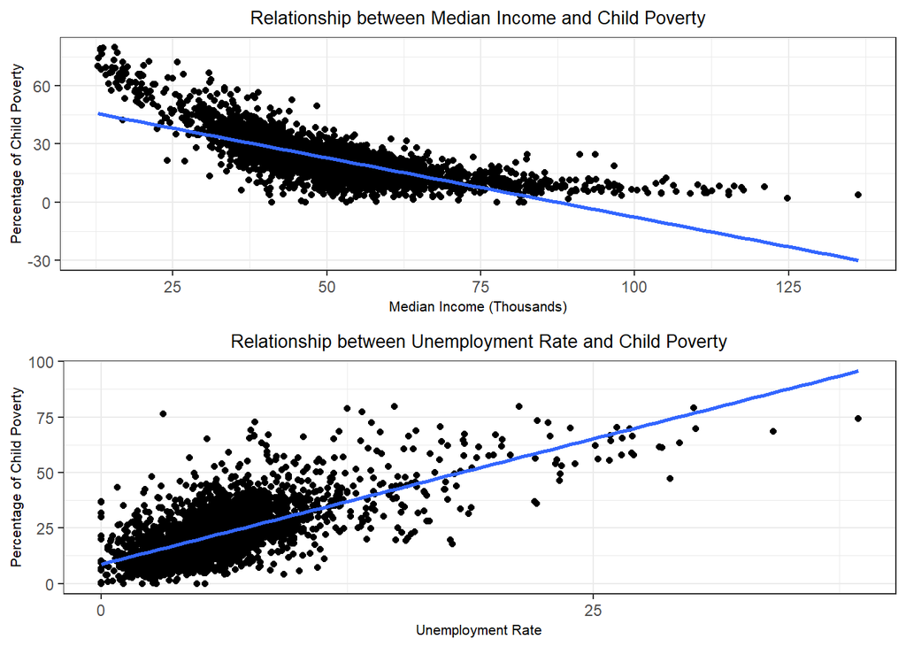

```r
median.income_graph <- ggplot(data=acs,aes(x = median.income, y = percent.child.poverty)) +
  geom_point() +
  geom_smooth(method=lm, formula = y ~ poly(x, 1), se = FALSE) +
  xlab("Median Income (Thousands)") +
  ylab("Percentage of Child Poverty") +
  scale_x_continuous(breaks=c(0,25,50,75,100,125,150)) +
  ggtitle("Relationship between Median Income and Child Poverty") +
  theme_bw() +
  theme(plot.title = element_text(hjust = 0.5)) +
  theme(axis.title.x = element_text(size = 8),
        axis.title.y = element_text(size = 8),
        plot.title = element_text(size = 10))

unemployment.rate_graph <- ggplot(data=acs,aes(x = unemployment.rate, y = percent.child.poverty)) +
  geom_point() +
  geom_smooth(method=lm, formula = y ~ poly(x, 1), se = FALSE) +
  xlab("Unemployment Rate") +
  ylab("Percentage of Child Poverty") +
  scale_x_continuous(breaks=c(0,25,50,75,100,125,150)) +
  ggtitle("Relationship between Unemployment Rate and Child Poverty") +
  theme_bw() +
  theme(plot.title = element_text(hjust = 0.5)) +
  theme(axis.title.x = element_text(size = 8),
        axis.title.y = element_text(size = 8),
        plot.title = element_text(size = 10))

grid.arrange(median.income_graph, unemployment.rate_graph)
```

## Part G

When I ran the regression for `percent.child.poverty` and `median.income` in **part C** the slope($m$) of `median.income` was $-0.613294$ which meant that a unit increase in `median.income` would cause a $-0.613294$ decrease in `percent.child.poverty`.

However, now that I am doing a **multivariate regression** with 2 independent variables `median.income` and `unemployment.rate` I noticed that the slope($m$) of `median.income` has decreased by $0.169458$ ($0.613294 - 0.443836 = 0.169458$). The slope($m$) that I have now is $-0.443836$. Although mathematically this would look like a **increase** in the context of this problem the change in slope is a **decrease** and a **negative thing**. This is because the now slope means that a unit increase in `median.income` reduces child poverty by $-0.443836$ percent. This percentage is **lower** than the rate that I got in the **bi-variate regression** which is a bad thing since my coefficient is telling me that a persons increase in income has a less effect in decreasing child poverty.

The decrease in slope for the `median.income` variable could also mean that the `unemployment.rate` variable has a greater effect in changing the child poverty rate. We could see this in **part F** with the strong correlations that `median.income` and `unemployment.rate` had with `percent.child.poverty`.

```r
summary(lm(percent.child.poverty ~ median.income + unemployment.rate, data = acs))
```

```
##
## Call:
## lm(formula = percent.child.poverty ~ median.income + unemployment.rate,
##     data = acs)
##
## Residuals:
##     Min      1Q  Median      3Q     Max
## -26.365  -3.902  -0.518   3.228  41.328
##
## Coefficients:
##                    Estimate Std. Error t value Pr(>|t|)
## (Intercept)       36.662660   0.638421   57.43   <2e-16 ***
## median.income     -0.443836   0.009438  -47.03   <2e-16 ***
## unemployment.rate  1.369099   0.038039   35.99   <2e-16 ***
## ---
## Signif. codes:  0 '***' 0.001 '**' 0.01 '*' 0.05 '.' 0.1 ' ' 1
##
## Residual standard error: 6.707 on 3215 degrees of freedom
##   (2 observations deleted due to missingness)
## Multiple R-squared:  0.6827, Adjusted R-squared:  0.6825
## F-statistic:  3459 on 2 and 3215 DF,  p-value: < 2.2e-16
```

## Part H

There is a slight decrease in the `median.income` and `unemployment.rate` coefficients if you compare them with the coefficients from **part G**. The difference is not too big and the explanation for the decrease is the new variables that are introduced in the regression analysis might have had a bigger impact in determining the percentage of child poverty which decreased the coefficient of the `median.income` and `unemployment.rate` variables (basically what happened in **part F** with the decrease in the coefficient of `median.income` when the `unemployment.rate` variable was introduced in the regression). The table below highlights the difference:

| Coefficient Difference (Part G - Part H) | Variable Name |
| --- | --- |
| $-0.443836 - (-0.397512) = -0.046324$ | median.income |
| $1.369099 - 1.193781 = 0.175318$ | unemployment.rate |

```r
#type is character, convert to factor
class(acs$census.region)
```

```
## [1] "character"
```

```r
acs$census.region <- factor(acs$census.region)
summary(lm(percent.child.poverty ~ median.income + unemployment.rate +
             census.region,
           data = acs))
```

```
##
## Call:
## lm(formula = percent.child.poverty ~ median.income + unemployment.rate +
##     census.region, data = acs)
##
## Residuals:
##     Min      1Q  Median      3Q     Max
## -26.492  -3.760  -0.362   3.239  34.828
##
## Coefficients:
##                         Estimate Std. Error t value Pr(>|t|)
## (Intercept)            33.280821   0.635661  52.356  < 2e-16 ***
## median.income          -0.397512   0.009289 -42.794  < 2e-16 ***
## unemployment.rate       1.193781   0.045132  26.451  < 2e-16 ***
## census.regionnortheast  1.825657   0.474129   3.851  0.00012 ***
## census.regionsouth      3.546065   0.269091  13.178  < 2e-16 ***
## census.regionwest       0.622232   0.358791   1.734  0.08297 .
## ---
## Signif. codes:  0 '***' 0.001 '**' 0.01 '*' 0.05 '.' 0.1 ' ' 1
##
## Residual standard error: 6.204 on 3134 degrees of freedom
##   (80 observations deleted due to missingness)
## Multiple R-squared:  0.6364, Adjusted R-squared:  0.6358
## F-statistic:  1097 on 5 and 3134 DF,  p-value: < 2.2e-16
```

## Part I

When adding the variable that says if a county is urban or not I noticed that there were many changes in the coefficients (some increased while others decreased. I have highlighted these changes in the table below.)

**NOTE**: I am making these comparisons from the results I got in **Part H**

[output not shown]

```r
acs$population.density <- (acs$population.density >= 1000)

#convert class to factor
class(acs$population.density)
```

```
## [1] "logical"
```

```r
acs$population.density <- factor(acs$population.density)

summary(lm(percent.child.poverty ~ median.income + unemployment.rate +
             census.region + population.density,
           data = acs))
```

```
##
## Call:
## lm(formula = percent.child.poverty ~ median.income + unemployment.rate +
##     census.region + population.density, data = acs)
##
## Residuals:
##     Min      1Q  Median      3Q     Max
## -26.254  -3.680  -0.342   3.248  34.514
##
## Coefficients:
##                         Estimate Std. Error t value Pr(>|t|)
## (Intercept)            34.528844   0.649262  53.182  < 2e-16 ***
## median.income          -0.419528   0.009616 -43.626  < 2e-16 ***
## unemployment.rate       1.156250   0.044954  25.721  < 2e-16 ***
## census.regionnortheast  1.413684   0.472503   2.992  0.00279 **
## census.regionsouth      3.371122   0.267441  12.605  < 2e-16 ***
## census.regionwest       0.677346   0.355426   1.906  0.05678 .
## population.densityTRUE  4.302792   0.547033   7.866 5.01e-15 ***
## ---
## Signif. codes:  0 '***' 0.001 '**' 0.01 '*' 0.05 '.' 0.1 ' ' 1
##
## Residual standard error: 6.145 on 3133 degrees of freedom
##   (80 observations deleted due to missingness)
## Multiple R-squared:  0.6434, Adjusted R-squared:  0.6427
## F-statistic: 942.1 on 6 and 3133 DF,  p-value: < 2.2e-16
```